# exam 1

## Now do some data work

For the next questions, you should work with the Household Pulse data that we’ve been using in class, to further explore influences upon how much social and emotional support people get. I’d like you to create an OLS linear model with a numeric version of social and emotional support as dependent variable and some other useful and/or interesting variables as X. Consider what other variables are likely to be relevant in predicting whether a person reports loneliness?

Note that this is how I created the dependent variable

```r
# Recode the SOCIAL1 variable into numeric levels for social/emotional support
Household_Pulse_data$s_e_support_numeric <- as.numeric(fct_recode(Household_Pulse_data$SOCIAL1,
    "5" = "always get social emotional support",
    "4" = "usually",
    "3" = "sometimes",
    "2" = "rarely",
    "1" = "never"))


# Convert income to numeric if necessary
Household_Pulse_data$INCOME <- as.numeric(Household_Pulse_data$INCOME)

# Fit the OLS linear model to show how income affects social/emotional support
ols_model <- lm(s_e_support_numeric ~ INCOME, data = Household_Pulse_data)

# View the summary of the OLS model
summary(ols_model)



# Load ggplot2 for visualization
library(ggplot2)

# Create a scatter plot with a regression line
ggplot(Household_Pulse_data, aes(x = INCOME, y = s_e_support_numeric)) +
  geom_point(alpha = 0.4) +  # Scatter plot of data points
  geom_smooth(method = "lm", se = TRUE, color = "blue") +  # Add regression line
  labs(title = "Effect of Income on Social/Emotional Support",
       x = "Income",
       y = "Social/Emotional Support Level (numeric)") +
  theme_minimal()
```

[output not shown]

```r
# Recode the SOCIAL1 variable into numeric levels for social/emotional support
Household_Pulse_data$s_e_support_numeric <- as.numeric(fct_recode(Household_Pulse_data$SOCIAL1,
    "5" = "always get social emotional support",
    "4" = "usually",
    "3" = "sometimes",
    "2" = "rarely",
    "1" = "never"))


# Convert income to numeric if necessary
Household_Pulse_data$p_e_price_numeric <- as.numeric(fct_recode(Household_Pulse_data$PRICESTRESS,
    "5" = "very stressed about price changes",
    "4" = "Moderate stress price changes",
    "3" = "a little stress price changes",
    "2" = "no stress",
    "1" = "NA"))

# Fit the OLS linear model to show how income affects social/emotional support
ols_model <- lm(s_e_support_numeric ~ INCOME, data = Household_Pulse_data)

# View the summary of the OLS model
summary(ols_model)
```

```
##
## Call:
## lm(formula = s_e_support_numeric ~ INCOME, data = Household_Pulse_data)
##
## Residuals:
##     Min      1Q  Median      3Q     Max
## -2.6513 -1.1115 -0.1239  0.7896  3.8885
##
## Coefficients:
##                                Estimate Std. Error t value Pr(>|t|)
## (Intercept)                     2.11154    0.01080  195.50   <2e-16 ***
## INCOMEHH income less than $25k  1.53975    0.01810   85.09   <2e-16 ***
## INCOMEHH income $25k - $34.9k   1.37993    0.01985   69.53   <2e-16 ***
## INCOMEHH income $35k - 49.9     1.29641    0.01864   69.54   <2e-16 ***
## INCOMEHH income $50k - 74.9     1.15852    0.01636   70.80   <2e-16 ***
## INCOMEHH income $75 - 99.9      1.09881    0.01729   63.55   <2e-16 ***
## INCOMEHH income $100k - 149     1.01236    0.01592   63.58   <2e-16 ***
## INCOMEHH income $150 - 199      0.93524    0.01936   48.30   <2e-16 ***
## INCOMEHH income $200k +         0.88178    0.01754   50.26   <2e-16 ***
## ---
## Signif. codes:  0 '***' 0.001 '**' 0.01 '*' 0.05 '.' 0.1 ' ' 1
##
## Residual standard error: 1.196 on 71143 degrees of freedom
## Multiple R-squared:  0.1343, Adjusted R-squared:  0.1342
## F-statistic:  1379 on 8 and 71143 DF,  p-value: < 2.2e-16
```

```r
# Fit the OLS model including INCOME as a predictor
ols_model <- lm(s_e_support_numeric ~ PRICESTRESS, data = Household_Pulse_data)

# View the summary of the model, which includes the p-value and confidence interval
summary(ols_model)
```

```
##
## Call:
## lm(formula = s_e_support_numeric ~ PRICESTRESS, data = Household_Pulse_data)
##
## Residuals:
##     Min      1Q  Median      3Q     Max
## -2.6512 -1.0282 -0.0282  0.7730  3.4806
##
## Coefficients:
##                                              Estimate Std. Error t value
## (Intercept)                                  2.519367   0.008193  307.50
## PRICESTRESSvery stressed about price changes 1.131795   0.012150   93.15
## PRICESTRESSModerate stress price changes     0.707591   0.013136   53.87
## PRICESTRESSa little stress price changes     0.508875   0.013320   38.20
## PRICESTRESSno stress                         0.332466   0.020854   15.94
##                                              Pr(>|t|)
## (Intercept)                                    <2e-16 ***
## PRICESTRESSvery stressed about price changes   <2e-16 ***
## PRICESTRESSModerate stress price changes       <2e-16 ***
## PRICESTRESSa little stress price changes       <2e-16 ***
## PRICESTRESSno stress                           <2e-16 ***
## ---
## Signif. codes:  0 '***' 0.001 '**' 0.01 '*' 0.05 '.' 0.1 ' ' 1
##
## Residual standard error: 1.21 on 71147 degrees of freedom
## Multiple R-squared:  0.1132, Adjusted R-squared:  0.1132
## F-statistic:  2272 on 4 and 71147 DF,  p-value: < 2.2e-16
```

```r
confint(ols_model)
```

```
##                                                  2.5 %    97.5 %
## (Intercept)                                  2.5033090 2.5354258
## PRICESTRESSvery stressed about price changes 1.1079805 1.1556103
## PRICESTRESSModerate stress price changes     0.6818437 0.7333386
## PRICESTRESSa little stress price changes     0.4827685 0.5349811
## PRICESTRESSno stress                         0.2915929 0.3733388
```

5. (25 points) Now create a linear model.
1. Explain what variables you choose to use as predictors. Consider whether polynomials in Age are important or interaction terms.
2. Do your estimates seem plausible? Are the estimates statistically significant?
1. I chose how much people stress about prices as a predictor for the social emotional support levels.
2. I do not think they are that plausible because realistically, I do not think this is a cause and effect relationship but rather the social emotional levels for people just tends to change along with people’s stress levels for price changes.

```r
# Fit the linear model
linear_model <- lm(s_e_support_numeric ~ PRICESTRESS, data = Household_Pulse_data)

# Get the summary of the model (optional to see coefficients and significance)
summary(linear_model)
```

```
##
## Call:
## lm(formula = s_e_support_numeric ~ PRICESTRESS, data = Household_Pulse_data)
##
## Residuals:
##     Min      1Q  Median      3Q     Max
## -2.6512 -1.0282 -0.0282  0.7730  3.4806
##
## Coefficients:
##                                              Estimate Std. Error t value
## (Intercept)                                  2.519367   0.008193  307.50
## PRICESTRESSvery stressed about price changes 1.131795   0.012150   93.15
## PRICESTRESSModerate stress price changes     0.707591   0.013136   53.87
## PRICESTRESSa little stress price changes     0.508875   0.013320   38.20
## PRICESTRESSno stress                         0.332466   0.020854   15.94
##                                              Pr(>|t|)
## (Intercept)                                    <2e-16 ***
## PRICESTRESSvery stressed about price changes   <2e-16 ***
## PRICESTRESSModerate stress price changes       <2e-16 ***
## PRICESTRESSa little stress price changes       <2e-16 ***
## PRICESTRESSno stress                           <2e-16 ***
## ---
## Signif. codes:  0 '***' 0.001 '**' 0.01 '*' 0.05 '.' 0.1 ' ' 1
##
## Residual standard error: 1.21 on 71147 degrees of freedom
## Multiple R-squared:  0.1132, Adjusted R-squared:  0.1132
## F-statistic:  2272 on 4 and 71147 DF,  p-value: < 2.2e-16
```

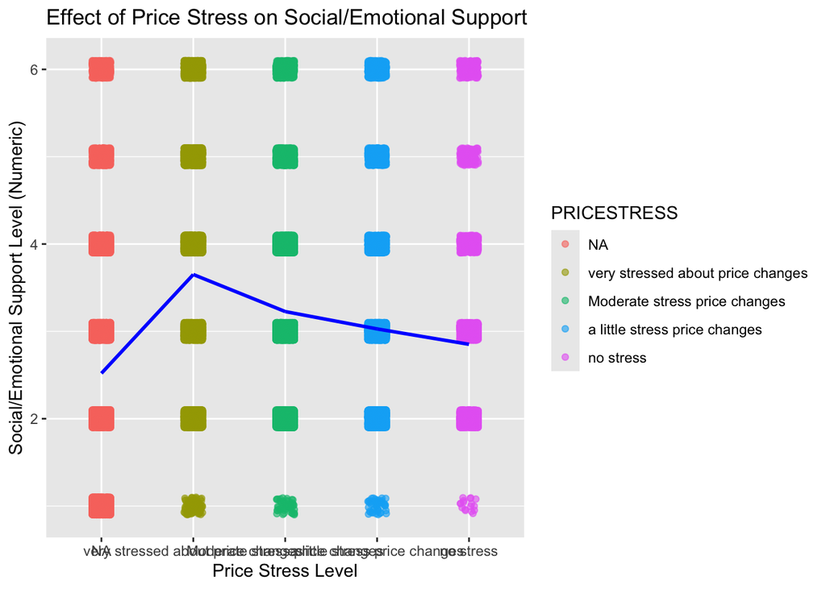

```r
 # Load ggplot2 for plotting
library(ggplot2)

# Create a dataset that contains the fitted values (predicted values) from the model
Household_Pulse_data$predicted_values <- predict(linear_model)

# Plot the linear model with the fitted values for each level of PRICESTRESS
ggplot(Household_Pulse_data, aes(x = PRICESTRESS, y = s_e_support_numeric)) +
  geom_point(aes(color = PRICESTRESS), position = position_jitter(width = 0.1, height = 0.1), alpha = 0.6) +  # Scatter plot of data points
  geom_line(aes(y = predicted_values, group = 1), color = "blue", size = 1) +  # Add the fitted line
  labs(title = "Effect of Price Stress on Social/Emotional Support",
       x = "Price Stress Level",
       y = "Social/Emotional Support Level (Numeric)") +
  ##format for Y axis + X Axis
theme(axis.text.y = element_text(angle = 0, hjust = .5))
```

```r
  theme_minimal()
```

[output not shown]

[output cut: 240 more lines]

[output not shown]

6. (15 points) How about a k-nn model? Impress me. (You might not have time for this one, I understand.)